# Name: Tanner Woods

# Question 1

## Question 1A

Treatment effect on $durat$ is approximately 24.70% greater duration in receiving workers' compensation for high-income workers.

## Question 1C

Treatment effect on $log(durat)$ is approximately 19.44% greater duration in receiving workers' compensation for high-income workers.

# Question 2

## Question 2A

Holding all else constant, a marginal year increase in $educ$ is predicted to produce an approximate decrease in children born of -0.0906. For the same marginal year increase in $educ$, the model predicts that a population of 100 women would have approximately 9.06 fewer children.

## Question 2B

With an F-stat = 62.62 from the regression $educ = \beta_0 + \beta_1(frsthalf)$ and the given assumption that Corr(Z,e) = 0, we can conclude that $frsthalf$ is a valid and realtively strong instrument for $educ$

## Question 2C

The 2SLS estimated effect of $educIV$ on $children$ with the IV $frsthalf$ for $educ$) is approximately 0.1559 fewer children per marginal year of education. This is an increase in treatment effect of approximately 72.08% relative to the previous OLS estimate.

## Question 2D

The OLS estimate for $educ$ with additional binary variables is approximately -0.0767 fewer children per marginal year of education.

The 2SLS estimate for $educIV$ with IV $frsthalf$ and additional binary variables is approximately -0.1203 fewer children per marginal year of education.

To interpret the negative estimated coefficients of $tv$, it could be reasonable to state that more time spent watching television is less time spent socializing with either potential partners or an existant partner. While I hesistate to state that watching television is something done solely by oneself, it is certainly an activity that may be categorized as "less social" or "nonsocial".

# Question 3

## Question 3A

I would expect that both $\gamma_5 < 0$ and $\gamma_6 < 0$ due to percentage increases in cigarette prices and state law restricting smoking likely having a negative relationship with total cigarettes smoked.

## Question 3B

With the equation in 3A, we assume that the components of $cigs$ are correlated with $cigs$ and not with the $log(income)$ model error term, $e_1$.

## Question 3C

OLS-estimated equation: $\hat {log(income)} \approx 7.7954 + 0.0017(cigs) + 0.0604(educ) + 0.0577(age) - 0.0006(age^2)$

2SLS-estimated equation: $\hat {log(income)} \approx 7.8548 + 0.1808(cigsIV) + 0.1448(educ) -0.0898(age) + 0.0011(age^2)$

From the above, the 2SLS estimate of $\beta_1$ produces a value approximately 100x greater than the estimate produced by OLS.

## Question 3D

Through a Hausman test for endogeneity, we can conclude that when $log(cigprice)$ and $restraun$ are included within the estimated model for $log(income)$ there is the existence of endogeneity. This also occurs with a joint test where both variables are included.

# Code

```python
import wooldridge as woo
import numpy as np
import pandas as pd
import statsmodels.formula.api as smf
import seaborn as sns
import matplotlib.pyplot as plt

from scipy import stats
from statsmodels.sandbox.regression.gmm import IV2SLS as ivs
```

```python
## Question 1A
## Sometimes the C() tool breaks and I have absolutely no idea why. Restarting the
## kernel seems to fix the issue, however.
Injury = woo.data('injury')
TreatModelQ1A = smf.ols("ldurat ~ highearn + male + married + age + C(injtype)", data = Injury).fit()
print(TreatModelQ1A.summary())
```

```
                            OLS Regression Results
==============================================================================
Dep. Variable:                 ldurat   R-squared:                       0.035
Model:                            OLS   Adj. R-squared:                  0.034
Method:                 Least Squares   F-statistic:                     22.61
Date:                Tue, 29 Nov 2022   Prob (F-statistic):           4.02e-46
Time:                        12:00:52   Log-Likelihood:                -11397.
No. Observations:                6844   AIC:                         2.282e+04
Df Residuals:                    6832   BIC:                         2.290e+04
Df Model:                          11
Covariance Type:            nonrobust
===================================================================================
                      coef    std err          t      P>|t|      [0.025      0.975]
-----------------------------------------------------------------------------------
Intercept           0.4625      0.098      4.705      0.000       0.270       0.655
C(injtype)[T.2]     0.7661      0.145      5.294      0.000       0.482       1.050
C(injtype)[T.3]     0.3825      0.086      4.468      0.000       0.215       0.550
C(injtype)[T.4]     0.6969      0.093      7.511      0.000       0.515       0.879
C(injtype)[T.5]     0.4759      0.086      5.519      0.000       0.307       0.645
C(injtype)[T.6]     0.4188      0.087      4.822      0.000       0.249       0.589
C(injtype)[T.7]     0.9108      0.175      5.219      0.000       0.569       1.253
C(injtype)[T.8]     0.5926      0.117      5.054      0.000       0.363       0.822
highearn            0.2470      0.036      6.931      0.000       0.177       0.317
male               -0.0341      0.041     -0.835      0.404      -0.114       0.046
married             0.0484      0.036      1.337      0.181      -0.023       0.119
age                 0.0089      0.001      6.813      0.000       0.006       0.012
==============================================================================
Omnibus:                       58.949   Durbin-Watson:                   1.918
Prob(Omnibus):                  0.000   Jarque-Bera (JB):               92.702
Skew:                           0.039   Prob(JB):                     7.41e-21
Kurtosis:                       3.565   Cond. No.                         585.
==============================================================================

Notes:
[1] Standard Errors assume that the covariance matrix of the errors is correctly specified.
```

```python
Injury
```

|  | durat | afchnge | highearn | male | married | hosp | indust | injtype | age | prewage | ... | head | neck | upextr | trunk | lowback | lowextr | occdis | manuf | construc | highlpre |
| --- | --- | --- | --- | --- | --- | --- | --- | --- | --- | --- | --- | --- | --- | --- | --- | --- | --- | --- | --- | --- | --- |
| 0 | 1.0 | 1 | 1 | 1.0 | 0.0 | 1 | 3.0 | 1 | 26.0 | 404.950012 | ... | 1 | 0 | 0 | 0 | 0 | 0 | 0 | 0.0 | 0.0 | 6.003764 |
| 1 | 1.0 | 1 | 1 | 1.0 | 1.0 | 0 | 3.0 | 1 | 31.0 | 643.825012 | ... | 1 | 0 | 0 | 0 | 0 | 0 | 0 | 0.0 | 0.0 | 6.467427 |
| 2 | 84.0 | 1 | 1 | 1.0 | 1.0 | 1 | 3.0 | 1 | 37.0 | 398.125000 | ... | 1 | 0 | 0 | 0 | 0 | 0 | 0 | 0.0 | 0.0 | 5.986766 |
| 3 | 4.0 | 1 | 1 | 1.0 | 1.0 | 1 | 3.0 | 1 | 31.0 | 527.799988 | ... | 1 | 0 | 0 | 0 | 0 | 0 | 0 | 0.0 | 0.0 | 6.268717 |
| 4 | 1.0 | 1 | 1 | 1.0 | 1.0 | 0 | 3.0 | 1 | 23.0 | 528.937500 | ... | 1 | 0 | 0 | 0 | 0 | 0 | 0 | 0.0 | 0.0 | 6.270870 |
| ... | ... | ... | ... | ... | ... | ... | ... | ... | ... | ... | ... | ... | ... | ... | ... | ... | ... | ... | ... | ... | ... |
| 7145 | 1.0 | 0 | 0 | 1.0 | 1.0 | 0 | 3.0 | 7 | 23.0 | 284.299988 | ... | 0 | 0 | 0 | 0 | 0 | 0 | 1 | 0.0 | 0.0 | 0.000000 |
| 7146 | 18.0 | 0 | 0 | 0.0 | 0.0 | 0 | 3.0 | 7 | 31.0 | 304.769592 | ... | 0 | 0 | 0 | 0 | 0 | 0 | 1 | 0.0 | 0.0 | 0.000000 |
| 7147 | 14.0 | 0 | 0 | 0.0 | 0.0 | 0 | 3.0 | 7 | 66.0 | 255.869995 | ... | 0 | 0 | 0 | 0 | 0 | 0 | 1 | 0.0 | 0.0 | 0.000000 |
| 7148 | 76.0 | 0 | 0 | 0.0 | NaN | 0 | 3.0 | 7 | 39.0 | 274.065186 | ... | 0 | 0 | 0 | 0 | 0 | 0 | 1 | 0.0 | 0.0 | 0.000000 |
| 7149 | 4.0 | 0 | 0 | 1.0 | 1.0 | 0 | 3.0 | 7 | 45.0 | 304.769592 | ... | 0 | 0 | 0 | 0 | 0 | 0 | 1 | 0.0 | 0.0 | 0.000000 |

7150 rows × 30 columns

```python
## Question 1B
ControlQ1B = Injury[(Injury['highearn'] == 0)]
TreatQ1B = Injury[(Injury['highearn'] == 1)]

stats.ttest_ind(ControlQ1B['afchnge'], TreatQ1B['afchnge'])
```

```
Ttest_indResult(statistic=-1.460190667562444, pvalue=0.14428162790185942)
```

```
0.19436737485889566
```

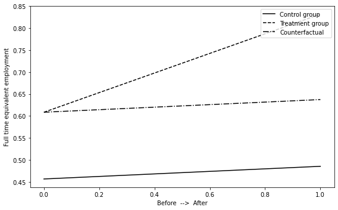

```python
## Question 1C
DiDModelQ1C = smf.ols('ldurat ~ highearn*afchnge + male + married + age + C(injtype)', data = Injury).fit()

b1 = DiDModelQ1C.params['Intercept']
b2 = DiDModelQ1C.params['highearn']
b3 = DiDModelQ1C.params['afchnge']
delta = DiDModelQ1C.params['highearn:afchnge']

## DiD points
C = b1 + b2 + b3 + delta
E = b1 + b3
B = b1 + b2
A = b1
D = E + (B - A)

## DiD Plot
plt.figure(figsize = (8, 5))
plt.xlim = [-0.01, 1.01];
#plt.ylim = [18, 24];
plt.xlabel('Before  -->  After');
plt.ylabel('Full time equivalent employment')
plt.plot([0,1],[A,E],linestyle = '-', color = 'black',
    label = 'Control group');
plt.plot([0,1],[B,C],linestyle = '--', color = 'black',
    label = 'Treatment group');
plt.plot([0,1],[B,D],linestyle = '-.', color = 'black',
    label = 'Counterfactual');
plt.legend(loc = 'upper right');
plt.tight_layout();

print(C-D)
```

```python
## Question 2A
Fertil = woo.data('FERTIL2')
ModelQ2A = smf.ols('children ~ educ + age + I(age**2)', data = Fertil).fit()
ModelQ2A.summary()
```

OLS Regression Results

| Dep. Variable: | children | R-squared: | 0.569 |
| --- | --- | --- | --- |
| Model: | OLS | Adj. R-squared: | 0.568 |
| Method: | Least Squares | F-statistic: | 1915. |
| Date: | Tue, 29 Nov 2022 | Prob (F-statistic): | 0.00 |
| Time: | 11:16:50 | Log-Likelihood: | -7835.6 |
| No. Observations: | 4361 | AIC: | 1.568e+04 |
| Df Residuals: | 4357 | BIC: | 1.570e+04 |
| Df Model: | 3 |  |  |
| Covariance Type: | nonrobust |  |  |

|  | coef | std err | t | P>\|t\| | [0.025 | 0.975] |
| --- | --- | --- | --- | --- | --- | --- |
| Intercept | -4.1383 | 0.241 | -17.200 | 0.000 | -4.610 | -3.667 |
| educ | -0.0906 | 0.006 | -15.298 | 0.000 | -0.102 | -0.079 |
| age | 0.3324 | 0.017 | 20.088 | 0.000 | 0.300 | 0.365 |
| I(age ** 2) | -0.0026 | 0.000 | -9.651 | 0.000 | -0.003 | -0.002 |

| Omnibus: | 203.406 | Durbin-Watson: | 1.868 |
| --- | --- | --- | --- |
| Prob(Omnibus): | 0.000 | Jarque-Bera (JB): | 715.951 |
| Skew: | 0.017 | Prob(JB): | 3.41e-156 |
| Kurtosis: | 4.985 | Cond. No. | 1.07e+04 |

Notes:  
[1] Standard Errors assume that the covariance matrix of the errors is correctly specified.  
[2] The condition number is large, 1.07e+04. This might indicate that there are  
strong multicollinearity or other numerical problems.

```python
## Question 2B
## Testing validity of instrument: Corr(Z,e) = 0 and Corr(Z,X) > 0
## Already assumed

## Testing strength of instrument: F-stat > 10
ModelQ2B = smf.ols('educ ~ frsthalf', data = Fertil).fit()
ModelQ2B.summary()
```

OLS Regression Results

| Dep. Variable: | educ | R-squared: | 0.014 |
| --- | --- | --- | --- |
| Model: | OLS | Adj. R-squared: | 0.014 |
| Method: | Least Squares | F-statistic: | 62.62 |
| Date: | Tue, 29 Nov 2022 | Prob (F-statistic): | 3.15e-15 |
| Time: | 11:24:41 | Log-Likelihood: | -12122. |
| No. Observations: | 4361 | AIC: | 2.425e+04 |
| Df Residuals: | 4359 | BIC: | 2.426e+04 |
| Df Model: | 1 |  |  |
| Covariance Type: | nonrobust |  |  |

|  | coef | std err | t | P>\|t\| | [0.025 | 0.975] |
| --- | --- | --- | --- | --- | --- | --- |
| Intercept | 6.3628 | 0.087 | 73.042 | 0.000 | 6.192 | 6.534 |
| frsthalf | -0.9377 | 0.118 | -7.913 | 0.000 | -1.170 | -0.705 |

| Omnibus: | 73.353 | Durbin-Watson: | 1.396 |
| --- | --- | --- | --- |
| Prob(Omnibus): | 0.000 | Jarque-Bera (JB): | 41.939 |
| Skew: | -0.027 | Prob(JB): | 7.82e-10 |
| Kurtosis: | 2.523 | Cond. No. | 2.72 |

Notes:  
[1] Standard Errors assume that the covariance matrix of the errors is correctly specified.

```python
## Question 2C
educ_IV = ModelQ2B.fittedvalues

ModelQ2C = smf.ols('children ~ educ_IV + age + I(age**2)', data = Fertil).fit()
ModelQ2C.summary()
```

OLS Regression Results

| Dep. Variable: | children | R-squared: | 0.547 |
| --- | --- | --- | --- |
| Model: | OLS | Adj. R-squared: | 0.546 |
| Method: | Least Squares | F-statistic: | 1751. |
| Date: | Tue, 29 Nov 2022 | Prob (F-statistic): | 0.00 |
| Time: | 12:45:10 | Log-Likelihood: | -7944.5 |
| No. Observations: | 4361 | AIC: | 1.590e+04 |
| Df Residuals: | 4357 | BIC: | 1.592e+04 |
| Df Model: | 3 |  |  |
| Covariance Type: | nonrobust |  |  |

|  | coef | std err | t | P>\|t\| | [0.025 | 0.975] |
| --- | --- | --- | --- | --- | --- | --- |
| Intercept | -4.0583 | 0.374 | -10.857 | 0.000 | -4.791 | -3.325 |
| educ_IV | -0.1559 | 0.049 | -3.212 | 0.001 | -0.251 | -0.061 |
| age | 0.3421 | 0.017 | 20.178 | 0.000 | 0.309 | 0.375 |
| I(age ** 2) | -0.0026 | 0.000 | -9.252 | 0.000 | -0.003 | -0.002 |

| Omnibus: | 199.972 | Durbin-Watson: | 1.814 |
| --- | --- | --- | --- |
| Prob(Omnibus): | 0.000 | Jarque-Bera (JB): | 610.421 |
| Skew: | 0.156 | Prob(JB): | 2.81e-133 |
| Kurtosis: | 4.806 | Cond. No. | 1.63e+04 |

Notes:  
[1] Standard Errors assume that the covariance matrix of the errors is correctly specified.  
[2] The condition number is large, 1.63e+04. This might indicate that there are  
strong multicollinearity or other numerical problems.

```python
## Question 2D
ModelQ2D_1 = smf.ols('children ~ educ + age + I(age**2) + electric + tv + bicycle', data = Fertil).fit()
print(ModelQ2D_1.summary())

ModelQ2D_2 = smf.ols('children ~ educ_IV + age + I(age**2) + electric + tv + bicycle', data = Fertil).fit()
print(ModelQ2D_2.summary())
```

```
                            OLS Regression Results
==============================================================================
Dep. Variable:               children   R-squared:                       0.576
Model:                            OLS   Adj. R-squared:                  0.575
Method:                 Least Squares   F-statistic:                     984.9
Date:                Tue, 29 Nov 2022   Prob (F-statistic):               0.00
Time:                        11:21:08   Log-Likelihood:                -7789.3
No. Observations:                4356   AIC:                         1.559e+04
Df Residuals:                    4349   BIC:                         1.564e+04
Df Model:                           6
Covariance Type:            nonrobust
===============================================================================
                  coef    std err          t      P>|t|      [0.025      0.975]
-------------------------------------------------------------------------------
Intercept      -4.3898      0.240    -18.267      0.000      -4.861      -3.919
educ           -0.0767      0.006    -12.075      0.000      -0.089      -0.064
age             0.3402      0.016     20.692      0.000       0.308       0.372
I(age ** 2)    -0.0027      0.000    -10.010      0.000      -0.003      -0.002
electric       -0.3027      0.076     -3.974      0.000      -0.452      -0.153
tv             -0.2531      0.091     -2.768      0.006      -0.432      -0.074
bicycle         0.3179      0.049      6.440      0.000       0.221       0.415
==============================================================================
Omnibus:                      196.639   Durbin-Watson:                   1.891
Prob(Omnibus):                  0.000   Jarque-Bera (JB):              675.502
Skew:                           0.009   Prob(JB):                    2.07e-147
Kurtosis:                       4.929   Cond. No.                     1.08e+04
==============================================================================

Notes:
[1] Standard Errors assume that the covariance matrix of the errors is correctly specified.
[2] The condition number is large, 1.08e+04. This might indicate that there are
strong multicollinearity or other numerical problems.
                            OLS Regression Results
==============================================================================
Dep. Variable:               children   R-squared:                       0.562
Model:                            OLS   Adj. R-squared:                  0.562
Method:                 Least Squares   F-statistic:                     931.9
Date:                Tue, 29 Nov 2022   Prob (F-statistic):               0.00
Time:                        11:21:08   Log-Likelihood:                -7858.0
No. Observations:                4356   AIC:                         1.573e+04
```

[output cut: 9 more lines]

```
I(age ** 2)    -0.0027      0.000     -9.807      0.000      -0.003      -0.002
electric       -0.4686      0.076     -6.161      0.000      -0.618      -0.319
tv             -0.4676      0.091     -5.136      0.000      -0.646      -0.289
bicycle         0.3037      0.050      6.056      0.000       0.205       0.402
==============================================================================
Omnibus:                      190.617   Durbin-Watson:                   1.872
Prob(Omnibus):                  0.000   Jarque-Bera (JB):              591.855
Skew:                           0.119   Prob(JB):                    3.02e-129
Kurtosis:                       4.790   Cond. No.                     1.63e+04
==============================================================================

Notes:
[1] Standard Errors assume that the covariance matrix of the errors is correctly specified.
[2] The condition number is large, 1.63e+04. This might indicate that there are
strong multicollinearity or other numerical problems.
```

```python
## Question 3C
Smoke = woo.data('smoke')

Model3QC_1 = smf.ols('lincome ~ cigs + educ + age + I(age**2)', data = Smoke).fit()
print(Model3QC_1.summary())

Model3QC_2A = smf.ols('cigs ~ lincome + educ + age + I(age**2) + lcigpric + restaurn', data = Smoke).fit()
cigs_IV = Model3QC_2A.fittedvalues
Model3QC_2B = smf.ols('lincome ~ cigs_IV + educ + age + I(age**2)', data = Smoke).fit()
print(Model3QC_2B.summary())
```

```
                            OLS Regression Results
==============================================================================
Dep. Variable:                lincome   R-squared:                       0.165
Model:                            OLS   Adj. R-squared:                  0.161
Method:                 Least Squares   F-statistic:                     39.61
Date:                Tue, 29 Nov 2022   Prob (F-statistic):           2.68e-30
Time:                        11:41:13   Log-Likelihood:                -798.50
No. Observations:                 807   AIC:                             1607.
Df Residuals:                     802   BIC:                             1630.
Df Model:                           4
Covariance Type:            nonrobust
===============================================================================
                  coef    std err          t      P>|t|      [0.025      0.975]
-------------------------------------------------------------------------------
Intercept       7.7954      0.170     45.741      0.000       7.461       8.130
cigs            0.0017      0.002      1.010      0.313      -0.002       0.005
educ            0.0604      0.008      7.642      0.000       0.045       0.076
age             0.0577      0.008      7.548      0.000       0.043       0.073
I(age ** 2)    -0.0006   8.34e-05     -7.563      0.000      -0.001      -0.000
==============================================================================
Omnibus:                      264.025   Durbin-Watson:                   1.908
Prob(Omnibus):                  0.000   Jarque-Bera (JB):              960.743
Skew:                          -1.531   Prob(JB):                    2.38e-209
Kurtosis:                       7.381   Cond. No.                     1.88e+04
==============================================================================

Notes:
[1] Standard Errors assume that the covariance matrix of the errors is correctly specified.
[2] The condition number is large, 1.88e+04. This might indicate that there are
strong multicollinearity or other numerical problems.
                            OLS Regression Results
==============================================================================
Dep. Variable:                lincome   R-squared:                       0.275
Model:                            OLS   Adj. R-squared:                  0.271
Method:                 Least Squares   F-statistic:                     75.99
Date:                Tue, 29 Nov 2022   Prob (F-statistic):           1.21e-54
Time:                        11:41:13   Log-Likelihood:                -741.58
No. Observations:                 807   AIC:                             1493.
Df Residuals:                     802   BIC:                             1517.
Df Model:                           4
Covariance Type:            nonrobust
===============================================================================
                  coef    std err          t      P>|t|      [0.025      0.975]
-------------------------------------------------------------------------------
Intercept       7.8548      0.159     49.429      0.000       7.543       8.167
cigs_IV         0.1808      0.016     11.076      0.000       0.149       0.213
educ            0.1448      0.011     13.630      0.000       0.124       0.166
age            -0.0898      0.015     -5.924      0.000      -0.120      -0.060
I(age ** 2)     0.0011      0.000      6.238      0.000       0.001       0.001
==============================================================================
Omnibus:                      170.917   Durbin-Watson:                   1.567
Prob(Omnibus):                  0.000   Jarque-Bera (JB):              459.193
Skew:                          -1.073   Prob(JB):                    1.94e-100
Kurtosis:                       6.008   Cond. No.                     1.89e+04
==============================================================================

Notes:
[1] Standard Errors assume that the covariance matrix of the errors is correctly specified.
[2] The condition number is large, 1.89e+04. This might indicate that there are
strong multicollinearity or other numerical problems.
```

```python
## Question 3D
## Hausman test for endogeneity
Smoke['intercept'] = 1
Smoke['agesqrd'] = Smoke['age'] ** 2

ModelQ3D_1 = ivs(endog = Smoke['lincome'],
                 exog = Smoke[['intercept','cigs', 'educ', 'age', 'agesqrd']],
                 instrument = Smoke[['intercept','lincome','educ','age','agesqrd', 'lcigpric']]).fit()

ModelQ3D_2 = ivs(endog = Smoke['lincome'],
                 exog = Smoke[['intercept','cigs', 'educ', 'age', 'agesqrd', 'lcigpric']],
                 instrument = Smoke[['intercept','lincome','educ','age','agesqrd', 'lcigpric', 'restaurn']]).fit()

ModelQ3D_3 = ivs(endog = Smoke['lincome'],
                 exog = Smoke[['intercept','cigs', 'educ', 'age', 'agesqrd', 'restaurn']],
                 instrument = Smoke[['intercept','lincome','educ','age','agesqrd', 'lcigpric', 'restaurn']]).fit()

ModelQ3D_4 = ivs(endog = Smoke['lincome'],
                 exog = Smoke[['intercept','cigs', 'educ', 'age', 'agesqrd', 'lcigpric','restaurn']],
                 instrument = Smoke[['intercept','lincome','educ','age','agesqrd', 'lcigpric', 'restaurn']]).fit()

# results are test statistic, p value, DOF
print(ModelQ3D_1.spec_hausman())
print(ModelQ3D_2.spec_hausman())
print(ModelQ3D_3.spec_hausman())
print(ModelQ3D_4.spec_hausman())
```

```
(648.98820526053, 1.185773710636208e-141, 2)
(115.65512256868843, 7.687926670921691e-26, 2)
(797.676183284311, 6.12093301789333e-174, 2)
(806.9251057173135, 1.3624906370403779e-174, 3)
```